# Jordan Lake Reservoir Model

Part5: Future trends (RCP8.5) - 2

Smitom Borah

05/25/2023

Time required to run the entire notebook: ~ 15 hours

# 1 Motivation

In this notebook, we develop future trends of TP in water and sediment columns under different climate scenarios. The final visualization are done in subsequent parts.

# 2 Edit log

*No new edit since creation.*

# 3 Loading packages

Following packages were used in this notebook.

```r
# Clearing the working environment----
cat("\014"); rm(list=ls(all=TRUE)); graphics.off()
# Start timer
Start_timer6 <- Sys.time()

# Loading the packages----
if (!require("pacman")) install.packages("pacman") ;
pacman::p_load(shinyjs,threejs,xlsx,minpack.lm,MuMIn,lme4,penalized,zoo,RColorBrewer,gridExtra,rowr,stringi,optimx,purrrlyr,Hmisc,leaps,caret,magrittr,plotly,remotes,RcppRoll,suncalc,adaptMCMC,TTR, truncnorm, readxl,lubridate, data.table,deSolve,zoo,tidyverse)
```

```r
library(lubridate)
library(caret)
library(randomForest)
```

## 3.1 Functions

We also developed several functions to make the computation efficient at several stages of coding. The final codes of some functions are presented here.

```r
#############
# Functions##
#############

## Function to determine the season of the year
Season <- function(Date){
  ##---------------------
  ## Argument list
  ## Date: date vector
  ##---------------------

  # Creating a month vector
  Mo <- month(Date)
  season <- rep(NA, length(Mo))
  for (i in 1:length(Mo)) {
    if (Mo[i] %in% c(1,2,3)){
      season[i] <- "Winter"
    } else if (Mo[i] %in% c(4,5,6)){
      season[i] <- "Spring"
    } else if (Mo[i] %in% c(7,8,9)){
      season[i] <- "Summer"
    } else {
      season[i] <- "Fall"
    }

  }
  return(season)
}
## test run
# Season(as.Date("2018-10-12", format = "%Y-%m-%d"))

#------------------------------------------------------------

## function to calculate 35days moving average of a column
MA35func <- function(x){
  ##----------------------------------------------------------
  ## Argument list
  ## x: column whose moving average needs to be calculated
  ##----------------------------------------------------------

  return(rollmean(x, 35, fill = NA, align = "right"))

}

#------------------------------------------------------------

## function to calculate 14days moving average of a column
MA14func <- function(x){
  ##----------------------------------------------------------
  ## Argument list
  ## x: column whose moving average needs to be calculated
  ##----------------------------------------------------------

  return(rollmean(x, 14, fill = NA, align = "right"))

}

#------------------------------------------------------------

## function to create bottom to surface P ratios in the forecast loop
## Note: Cannot be tested outside the loop
Pratios.fun <- function(smplyrvec, bt.df = AvgT_85.35ma.d, st.df = AvgT_85.14ma.d){
  ##------------------------------------------------------------
  ## Argument list
  ## smplyrvec:  vector of sampled historical years for
  ##             historical data in the prediction years
  ## bt.df:      data frame of daily 35d moving average of
  ##             air temperature from 32 GCFs (bottom temp)
  ## st.df:      data frame of daily 35d moving average of
  ##             air temperature from 32 GCFs (surface temp)
  ##------------------------------------------------------------

  WS.df <- WS.func(Smpleyr = smplyrvec)

  RFfactorsDf <- data.frame(Date =  WS.df$Date,
                            Average.Wind.Speed.ms =  WS.df$`Average Wind Speed (ms)`)

  RFfactorsDf <- merge (RFfactorsDf,
                          bt.df[,c(1,sample(seq(5,36), size = 1))],
                          by = "Date", all.x = T)

  RFfactorsDf <- merge (RFfactorsDf,
                          st.df[,c(1,sample(seq(5,36), size = 1))],
                          by = "Date", all.x = T)

  hypo.PinpDFall <- PinpDFall[,c("Date", "H2m", "H3m", "H4m")]

  # Create DateTime object for entire duration
  hypo.p.o.r <- data.frame(Date = seq(as.Date(date.cali.daily[1]), as.Date(date.pred.daily[length(date.pred.daily)]),  by = "1 day"))
  # merging
  hypo.PinpDFall <- merge(hypo.p.o.r, hypo.PinpDFall, by = "Date", all.x = T)

  # Filling the daily values from the monthly values
  hypo.PinpDFall <- zoo::na.locf(zoo::na.locf(hypo.PinpDFall), fromLast = T)

  # Segment 2
  RFfactorsDf2 <- merge(hypo.PinpDFall[,c("Date", "H2m")], RFfactorsDf, by = "Date", all.x = T)

  ## adding surface sampling, segment and month details
  RFfactorsDf2 <- RFfactorsDf2 %>% mutate(Depth_surface = rep(1.5, nrow(RFfactorsDf2)),
                                          Month = month(Date),
                                          Segment = rep(2, nrow(RFfactorsDf2)))
  ## Changing the column names
  col.names <- c("Date", "Depth_Bottom", "Average.Wind.Speed.ms", "BottomTemp", "SurfaceTemp", "Depth_surface", "Month", "Segment" )
  colnames(RFfactorsDf2) <- col.names

  ## Rearranging the terms
  rearr.vec <- c("Date","Average.Wind.Speed.ms","BottomTemp","SurfaceTemp", "Month", "Depth_surface", "Depth_Bottom", "Segment")
  RFfactorsDf2 <- RFfactorsDf2[,rearr.vec]

  # Segment 3
  RFfactorsDf3 <- merge(hypo.PinpDFall[,c("Date", "H3m")], RFfactorsDf, by = "Date", all.x = T)

  ## adding surface sampling, segment and month details
  RFfactorsDf3 <- RFfactorsDf3 %>% mutate(Depth_surface = rep(1.5, nrow(RFfactorsDf3)),
                                          Month = month(Date),
                                          Segment = rep(3, nrow(RFfactorsDf3)))
  ## Changing the column names
  colnames(RFfactorsDf3) <- col.names

  ## Rearranging the terms
  RFfactorsDf3 <- RFfactorsDf3[,rearr.vec]

  # Segment 4
  RFfactorsDf4 <- merge(hypo.PinpDFall[,c("Date", "H4m")], RFfactorsDf, by = "Date", all.x = T)

  ## adding surface sampling, segment and month details
  RFfactorsDf4 <- RFfactorsDf4 %>% mutate(Depth_surface = rep(1.5, nrow(RFfactorsDf4)),
                                          Month = month(Date),
                                          Segment = rep(4, nrow(RFfactorsDf4)))
  ## Changing the column names
  colnames(RFfactorsDf4) <- col.names

  ## Rearranging the terms
  RFfactorsDf4 <- RFfactorsDf4[,rearr.vec]

  # Rbs values
  Rbs2 <- data.frame(Date = RFfactorsDf2$Date, Rbs2 = predict(BoSuP.rf, newdata = select(RFfactorsDf2, -Date))) %>%
    mutate(Month = month(Date),
           Year = year(Date)) %>%
    group_by(Year,Month) %>%
    summarise(Rbs2 = mean(Rbs2))

  Rbs3 <- data.frame(Date = RFfactorsDf3$Date, Rbs3 = predict(BoSuP.rf, newdata = select(RFfactorsDf3, -Date))) %>%
    mutate(Month = month(Date),
           Year = year(Date)) %>%
    group_by(Year,Month) %>%
    summarise(Rbs3 = mean(Rbs3))

  Rbs4 <- data.frame(Date = RFfactorsDf4$Date, Rbs4 = predict(BoSuP.rf, newdata = select(RFfactorsDf4, -Date))) %>%
    mutate(Month = month(Date),
           Year = year(Date)) %>%
    group_by(Year,Month) %>%
    summarise(Rbs4 = mean(Rbs4))

  return(list(Rbs2, Rbs3, Rbs4))
}
```

# 4 Loading the Random Forest Model

```r
# loading the RWorkspace of JLPMv016p004.Rmd
load("RWorkSpaces/JLPMv016p004_1.RData")

# Check the Random Forest model
BoSuP.rf
```

```
Call:
 randomForest(formula = BoSuP ~ ., data = select(SegPfac1, -Date),      mtry = 3, ntree = 1000, importance = TRUE, na.action = na.omit)
               Type of random forest: regression
                     Number of trees: 1000
No. of variables tried at each split: 3

          Mean of squared residuals: 1.318645
                    % Var explained: 34.81
```

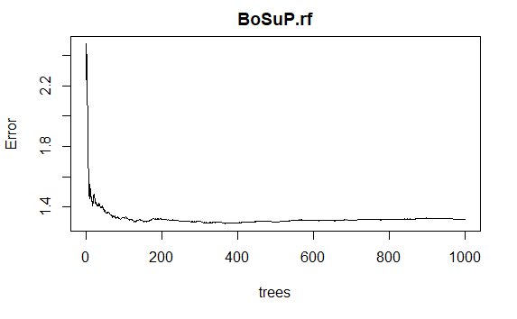

```r
# Plotting the error plot
plot(BoSuP.rf)
```

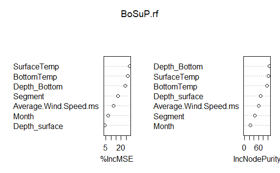

```r
# plotting the variable importance plot
varImpPlot(BoSuP.rf)
```

```r
# Coefficient of determination
print(paste0("Coefficient of determination: ", VarExp(BoSuP.rf$predicted, BoSuP.rf$y)))
```

```
[1] "Coefficient of determination: 0.348"
```

# 5 General Plotting specification

To maintain the consistency in the plots developed in this notebook, we create a ggplot object to store the basic specification for each plot.

```r
# General plot specification
plot_basics <- theme_bw()+
  theme(legend.background = element_blank(),
        panel.grid.major = element_blank(),
        panel.grid.minor = element_blank(),
        legend.text.align = 0,
        text = element_text(size = 10),
        legend.text = element_text(size = 10, color = "black"),
        axis.title = element_text(size = 10, color = "black"),
        axis.text = element_text(size = 10, color = "black"))
```

# 6 Calibration and forecast period

```r
# Daily period of record and prediction----
## Daily period of record
date.cali.daily <- floor_date(seq(ymd('1983-01-01'),
                                  ymd('2018-12-31'),
                                  by = 'day'),
                        unit = "day")

## Period of prediction
date.pred.daily <- floor_date(seq(ymd('2019-01-01'),
                                  ymd('2090-12-31'),
                                  by = 'day'),
                        unit = "day")


# Monthly period of record and prediction----
## Period of record
date_cali <- floor_date(seq(ymd('1983-01-01'),ymd('2018-12-01'), by = 'month'), unit = "month")

## Period of prediction
date_scen <- floor_date(seq(ymd('2019-01-01'),ymd('2090-12-01'), by = 'month'), unit = "month")
```

# 7 Wind speed

It was found in one of the previous file that downscaled winds speed data set was inadequate. So, we used the the randomly sampled windspeed data from historical records (1999-2018) to create future simulations. Here. we develop a function to create a data frame of wind speed in the future forecasting loop.

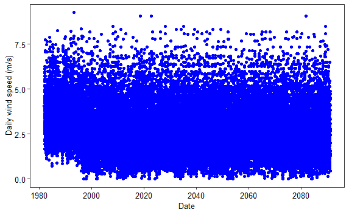

```r
# year range for historical simulation
st.year <- 1999 # Start year
ed.year <- 2018 # end year

# number of years in prediction
st.pred.yr <- 2019
ed.pred.yr <- 2090
Tot.yrs <- ed.pred.yr-st.pred.yr+1

# All the historial years
hist.allyr <- seq(st.year, ed.year, by = 1)

# prediction years
pred.Actyr <- seq(st.pred.yr,ed.pred.yr,1)

# Sampling the years for future projection
set.seed(5000)
pred.allyr <- sample(hist.allyr,Tot.yrs,replace = T )

## Converting the observed wind speed into m/s
RDU_wind$`Average Wind Speed (ms)` <- RDU_wind$`Average Wind Speed (mph)`*0.447

# Function to account for the leap year in the Wind speed data predictions
WS.func <- function(obsWS = RDU_wind,
                    histyr = hist.allyr,
                    predyr = pred.Actyr,
                    Smpleyr = pred.allyr,
                    predDate.d = date.pred.daily){
  ##-------------------------------------------------------------------------
  ## Argument list
  ## obsWS: Observed wind speed
  ## histyr: vector of historical years, most likely 1999 to 2018
  ## predyr: vector of prediction years, most likely 2019 to 2090
  ## Smpleyr: vector of sampled historical years for historical data in the prediction years
  ## predDate.d : vector of daily prediction dates, most likely 01/01/2019 to 12/31/2099
  ##-------------------------------------------------------------------------

  pred.WSdf <- data.frame()
  for (ii in 1:Tot.yrs){

    tdf <- RDU_wind[which(year(RDU_wind$Date)%in%histyr),] %>%
      mutate(Year = year(Date))
    tdf <- tdf[which(tdf$Year %in%Smpleyr[ii] ),]


    if(predyr[ii]%%4!=0 && Smpleyr[ii]%%4==0){
      tdf <- tdf[-which(tdf$Date==as.Date(paste0("2/29/",Smpleyr[ii]), format = "%m/%d/%Y")),]
    }

    if (predyr[ii]%%4==0 && Smpleyr[ii]%%4!=0){
      ExtraDay <- data.frame(Date = as.Date(paste0("2/28/",Smpleyr[ii]), format = "%m/%d/%Y"),
                             `Average Wind Speed (mph)` = NA,
                             `Maximum Wind Speed (mph)` = NA,
                             `Average Wind Speed (ms)` = NA,
                             Year = Smpleyr[ii])
      tdf[nrow(tdf)+1,] <- ExtraDay
      tdf %<>% arrange(tdf$Date)
    }
    pred.WSdf %<>%bind_rows(.,tdf)
  }

  # Data tidying
  ## Changing the date and years
  pred.WSdf$Date <- predDate.d
  pred.WSdf$Year <- year(pred.WSdf$Date)

  ## combining the historical and predicted windspeed
  WindSpeed <- obsWS %>% mutate(Year = year(Date))
  WindSpeed <- rbind(WindSpeed, pred.WSdf)

  ## Imputing the missing data with previous data points
  WindSpeed <- zoo::na.locf(na.locf(WindSpeed), fromLast = T)
  # WindSpeed <- na.locf(na.locf(WindSpeed))

  return(WindSpeed)

}

# Checking the function
WindSpeed <- WS.func()

### Daily variation
ggplot(WindSpeed, aes(x = Date, y = `Average Wind Speed (ms)`))+
  geom_point(color = "blue")+
  # geom_line(color = "grey", alpha = 0.3)+
  labs(x = "Date",
       y = "Daily wind speed (m/s)")+
  plot_basics
```

# 8 Future Trends under RCP8.5

## 8.1 Inputs

In this section, we specify the inputs required to run the model

```r
# Percentage reduction in external P loading
exPH00 <- -0

# Number of posterior parameter samples
N <- 1000

# Loading the First-order workspace
load("RWorkSpaces/JLPMv016p001_1.RData")

# Inputs
Popt_par <- opt_prm
PinpDF <- RoutMOdin[,!colnames(RoutMOdin) %in% c("...1")]
Pinp <- RoutMOdin %>% creaInp(.,tlim=nrow(.))
Pico <- Const_lis
Pico$timestep <- 1:length(Pinp$A1t)
Pico$vs_scal <- vs_scal
Pico$par_scal <- par_scal

# Changing the Date of PinpDF
PinpDF$Date <- as.Date(paste0(PinpDF$mo,"/1/",PinpDF$year), format = "%m/%d/%Y")

# Adding the hypolimnion middepths
# loading the monthly hypolimnetic depths data
hypo.midDepth.raw <- read_excel("DataFiles/HypolimnionCalcs.xlsx",
                                sheet = "Sheet1", range = "A2:Y434")%>%
  rename(.,
         H1m = `H1 m...22`,
         H2m = `H2 m...23`,
         H3m = `H3 m...24`,
         H4m = `H4 m...25`)

# Only segments 2-4
hypo.midDepth <- hypo.midDepth.raw[,c("start_d", "H2m", "H3m", "H4m")]

# renaming a column
colnames(hypo.midDepth)[1] <- "Date"
hypo.midDepth$Date <- as.Date(hypo.midDepth$Date)

# Adding the hypolimnion mid-depths to PinpDF
PinpDF <- merge(PinpDF,hypo.midDepth,by = "Date", all.x = T )

# sampling set of posterior samples
# Setting seed
set.seed(500)
postPsmpl <- RAM$samples[sample(seq((nrow(RAM$samples)-25000),nrow(RAM$samples)),
                                N,
                                replace = F),]

# Separating the observations
Pobs <- obs %>% transmute(cale_date=myd(paste0(as.character(ym),"-1")),
                          TPugL = obs,variable)

# Check for segments
all_seg <- Pobs %>% pull(variable) %>% unique # should be 4 : "C1","C2","C3" and "C4"

# Loading the functions file
source("Pmodels/JLPMfunv16p005.R")
```

[output not shown]

```r
# Projection years
yrs_prj <- date_scen %>% year %>% unique %>% length()
```

# 9 Average Mass in the historical years

Let us calculate the average mass in each segment in the historical years. This information is useful for future year P concentration predictions.

```r
# average Mass in each segments
## Segment 1
meanM1 <- mean(MassFlows[which(MassFlows$year %in% c(1999,2018)),]$M1)

## Segment 2
meanM2 <- mean(MassFlows[which(MassFlows$year %in% c(1999,2018)),]$M2)

## Segment 3
meanM3 <- mean(MassFlows[which(MassFlows$year %in% c(1999,2018)),]$M3)

## Segment 4
meanM4 <- mean(MassFlows[which(MassFlows$year %in% c(1999,2018)),]$M4)

# Quick view
AvgMoP.df<- data.frame(Segment = c(1,2,3,4), Avg.P.Mass_kg_mo = c(meanM1, meanM2, meanM3, meanM4))
AvgMoP.df
```

| Segment | Avg.P.Mass_kg_mo |
| --- | --- |
| 1 | 1850.067 |
| 2 | 3736.194 |
| 3 | 5534.170 |
| 4 | 4302.757 |

## 9.1 Air temperature

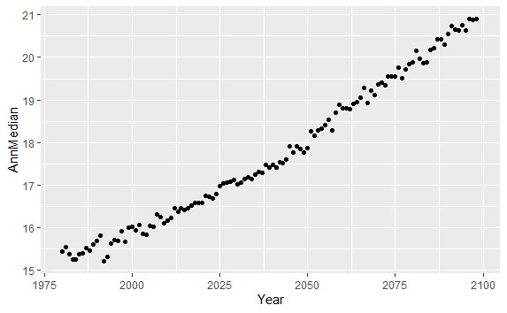

```r
# Loading minimum temperature data----
## 1980-2050
MinT_85_raw1 <- read.csv("DataFiles/Loca_Temp_min_85.csv", header = TRUE)

### Adding date and median temperature column for quick plot
MinT_85_1 <- MinT_85_raw1 %>%
  mutate(Date = as.Date(paste0(Year,"/",Month,"/",Day)),
         MedianT = apply(MinT_85_raw1[,c(4:35)], 1, median))

## 2051-2099
MinT_85_raw2 <- read.csv("DataFiles/Loca_Temp_min_85_20512099.csv", header = FALSE)

### Adding column names
colnames(MinT_85_raw2) <- c("Year", "Month", "Day", paste0("Temp",c(1:32)))

### making all the temperature data numeric
MinT_85_raw2[,4:35] <- as.numeric(unlist(MinT_85_raw2[,4:35]))
### Adding date and median temperature column for quick plot
MinT_85_2 <- MinT_85_raw2 %>%
  mutate(Date = as.Date(paste0(Year,"/",Month,"/",Day), format = "%Y/%m/%d"),
         MedianT = apply(MinT_85_raw2[,c(4:35)], 1, median))

## combining the two data frames
MinT_85 <- rbind(MinT_85_1,MinT_85_2)

# Loading maximum temperature data----
## 1980-2050
MaxT_85_raw1 <- read.csv("DataFiles/Loca_Temp_max_85.csv", header = TRUE)

### Adding date and median temperature column for quick plot
MaxT_85_1 <- MaxT_85_raw1 %>%
  mutate(Date = as.Date(paste0(Year,"/",Month,"/",Day)),
         MedianT = apply(MaxT_85_raw1[,c(4:35)], 1, median))

## 2050-2099
MaxT_85_raw2 <- read.csv("DataFiles/Loca_Temp_max_85_20512099.csv", header = FALSE)

### Adding column names
colnames(MaxT_85_raw2) <- c("Year", "Month", "Day", paste0("Temp",c(1:32)))

### making all the temperature data numeric
MaxT_85_raw2[,4:35] <- as.numeric(unlist(MaxT_85_raw2[,4:35]))
### Adding date and median temperature column for quick plot
MaxT_85_2 <- MaxT_85_raw2 %>%
  mutate(Date = as.Date(paste0(Year,"/",Month,"/",Day)),
         MedianT = apply(MaxT_85_raw2[,c(4:35)], 1, median))

# combining the two data frames
MaxT_85 <- rbind(MaxT_85_1,MaxT_85_2)

# daily temperature
AvgT_85 <- bind_rows(MinT_85, MaxT_85) %>%
  group_by(Date) %>%
  summarise_all(list(mean))

# Plotting the moving median average temperature
AvgT_85 %>% group_by(Year) %>% summarise(AnnMedian = mean(MedianT)) %>% ggplot()+
  geom_point(aes(x = Year, y = AnnMedian))
```

```r
# 5 week moving average
AvgT_85.35ma.d <- AvgT_85 %>% mutate_at(c(5:36), MA35func) %>% drop_na()

# Data tidying
AvgT_85.35ma.d <- AvgT_85.35ma.d[,c(1:36)]
colnames(AvgT_85.35ma.d) <- c("Date", "Year", "Month", "Day", paste0("Temp.35dMA.",c(1:32)))

# 2 week moving average
AvgT_85.14ma.d <- AvgT_85 %>% mutate_at(c(5:36), MA14func) %>% drop_na()

# Data tidying
AvgT_85.14ma.d <- AvgT_85.14ma.d[,c(1:36)]
colnames(AvgT_85.14ma.d) <- c("Date", "Year", "Month", "Day", paste0("Temp.14dMA.",c(1:32)))
```

## 9.2 Water temperature

We developed a linear model to predict the bottom water temperature from the air temperature (2m above surface). Based on our preliminary investigations, we found the 5week moving average yielded the best results.The linear model is as follows:

$$Bottom\ water\ temperature = 0.89\times
(35day m.a.\ air temperature)+2.58$$

```r
# prediction water temperature data
predWtrT85.35ma.d <- AvgT_85.35ma.d[which(AvgT_85.35ma.d$Year%in%c(2019:2099)),]

# Applying the linear progrssion model
predWtrT85.35ma.d[,c(5:36)] <- 0.89*predWtrT85.35ma.d[,c(5:36)]+2.58
tmp85_dat  <- predWtrT85.35ma.d %>% group_by(Year, Month) %>%
  summarise_at(.,.vars = colnames(predWtrT85.35ma.d)[5:36], mean) %>% as.data.frame()

tmp85_dat <- tmp85_dat %>%
  mutate(Art_date = as.Date(paste0(Year,"/",Month, "/01")))

## getting only temperature between 2019-2090
tmp85_dat <- tmp85_dat[which(tmp85_dat$Art_date %in% date_scen),]

## Adding columns for median, min and max temperature
tmp85_dat <- tmp85_dat %>% mutate(Median_temp = apply(tmp85_dat[,3:34], 1, median),
                                  min_temp = apply(tmp85_dat[,3:34], 1, min),
                                  max_temp = apply(tmp85_dat[,3:34], 1, max))
```

## 9.3 Generating future projections

```r
# setting a timer
start_time <- Sys.time()

# A vector of historical years
# set.seed(123)
set.seed(500)
Hyr <- sample(rep(seq(1999,2018), times = 3 ), 60, replace = F)

# Number of historical years
nhist <- length(Hyr)

HistYears.df <- data.frame(y2019 = Hyr)

for (y in 1:(yrs_prj-1)) {
  Mod <- paste0("y",y+2019)
  Hyr <- c(Hyr[2:nhist],Hyr[1])
  HistYears.df <- cbind(HistYears.df,Hyr)
  colnames(HistYears.df)[ncol(HistYears.df)] <- Mod
}

HistYears.df <- HistYears.df%>%t%>% as.data.frame()

set.seed(456)
HistYears.df <- HistYears.df[sample(1:nrow(HistYears.df),nrow(HistYears.df),replace = FALSE ),]

# Turing the columns into a list of input future series
HistYears <- list()
for(i in 1:ncol(HistYears.df)) {             # Using for-loop to add columns to list
  HistYears[[i]] <- HistYears.df[[i]]
}

# Number of parameter sets to be considered for each year TODO change the npar value for the final simulation
npar <- 1000 #TODO select either 100 or 1000 in the final code. Previously it was 100

# Sampling say 100 parameter sets from 1000 without replacement
set.seed(456)
parset <- sample(1:nrow(postPsmpl), npar, replace= FALSE)

# Creating a list to store all the dataframes
PparhydH00 <- list()
PallH00 <- list()

# number of times random error are added
rnum <- 1


for (i in 1:nhist){
  # i <- 1

  ## Scenario selection
  EP_red <- exPH00


  ## Future years with one year data from the historical years
  PinpFut <- data.frame()
  for (ii in 1:yrs_prj){
    # ii <- 1
    tdf <- PinpDF[which(PinpDF$year %in% HistYears[[i]][ii]),]
    tdf$Date <- as.Date(tdf$Date)
    tdf[1, !(colnames(tdf) %in% c("Date", "yrmo"))] <- as.numeric(tdf[1, !(colnames(tdf) %in% c("Date", "yrmo"))])
    PinpFut %<>%bind_rows(.,tdf)
  }

  # Correcting order of t
  PinpFut$t <- seq(1,nrow(PinpFut))

  # change input concentrations according to scenario
  PinpFut$Temperature <- tmp85_dat[,sample(seq(3,34), size = 1, replace = T)]

  # Getting the dates right
  PinpFut$Date <- as.Date(date_scen)


  # Combining calibration and prediction datasets together
  PinpDFall <- PinpDF %>% as_tibble() %>% bind_rows(.,PinpFut) %>%
    rowid_to_column(., "ro")

  # Accounting for imaginary volume addition/removal in future years
  PinpDF <- PinpVolBal.fun(PinpDFall1 = PinpDF)
  PinpFut <- PinpVolBal.fun(PinpDFall1 = PinpFut)
  PinpDFall <- PinpVolBal.fun()

  # Correcting the years
  PinpFut$year <- year(PinpFut$Date)
  PinpDFall$year <- year(PinpDFall$Date)

  # Dataset to calculate the bottom to surface P ratios
  BotSutPrat <- Pratios.fun(smplyrvec = HistYears[[i]])
  Pico$Rbs2 <- BotSutPrat[[1]]$Rbs2
  Pico$Rbs3 <- BotSutPrat[[2]]$Rbs3
  Pico$Rbs4 <- BotSutPrat[[3]]$Rbs4

  # Model run for calibration part
  Pico_tmp1 <- Pico
  Pico_tmp2 <- Pico

  # Arranging the dataset
  PinpCaSc <- PinpDFall %>% creaInp(.,tlim=nrow(.))
  Pico$timestep <- 1:length(PinpCaSc$A1t)

  # Model run for calibration part
  # Arranging the calibration dataset
  # PinpCaSc1 <- PinpDF %>% creaInp(.,tlim=nrow(.))
  PinpCaSc1 <- PinpDFall[1:(nrow(PinpDF)+1),] %>% creaInp(.,tlim=nrow(.))
  Pico_tmp1$timestep <- 1:length(PinpCaSc1$A1t)
  Pico_tmp1$Rbs2 <- Pico_tmp1$Rbs2[1:length(PinpCaSc1$A1t)]
  Pico_tmp1$Rbs3 <- Pico_tmp1$Rbs2[1:length(PinpCaSc1$A1t)]
  Pico_tmp1$Rbs4 <- Pico_tmp1$Rbs2[1:length(PinpCaSc1$A1t)]


  # Temporary objects to store model outputs
  ## object to store outputs w/ (parameter + hydrometeorologic) uncertainty
  PparhydH00x <- list()
  PallH00x <- list()

  # Generating model outputs based on each historical year and
  # each different parameter sets
  for (j in 1: npar){
    # j <- 1
    # Selecting a parameter set
    parPih <- postPsmpl[parset[j],]

    # Model run
    TempDF1 <- mod_wrap_pred_v3(inp_dat=PinpCaSc1,
                               FixInp_lis=Pico_tmp1,
                               CalPar=parPih) %>%
    dplyr::select(matches("C1|C.sur"),M1, M2, M3, M4, S1,S2,S3,S4,temperature, V1, V2, V3, V4) %>%
    `colnames<-`(substring(colnames(.),1,2)) %>%
    add_column(.,cale_date=c(date_cali, date_scen[1]))
    # %>%
    #   mutate(S1res = (parPih["Rs"]/100)*S1*(parPih["ThetaR"]^(te-20)),
    #          S2res = (parPih["Rs"]/100)*S2*(parPih["ThetaR"]^(te-20)),
    #          S3res = (parPih["Rs"]/100)*S3*(parPih["ThetaR"]^(te-20)),
    #          S4res = (parPih["Rs"]/100)*S4*(parPih["ThetaR"]^(te-20)),
    #          Sconc = (S1+S2+S3+S4)/(49.02*10^3),
    #          Sres = (S1res+S2res+S3res+S4res)/(49.02*10^3))

    # Model run for the future projections
    # PinpCaSc2 <- rbind(PinpDF[nrow(PinpDF),], PinpFut) %>% creaInp(.,tlim=nrow(.))
    PinpCaSc2 <- PinpFut %>% creaInp(.,tlim=nrow(.))
    Pico_tmp2$timestep <- 1:length(PinpCaSc2$A1t)


    Pico_tmp2$Rbs2 <- BotSutPrat[[1]]$Rbs2[(nrow(PinpDF)+1):nrow(PinpDFall)]
    Pico_tmp2$Rbs3 <- BotSutPrat[[2]]$Rbs3[(nrow(PinpDF)+1):nrow(PinpDFall)]
    Pico_tmp2$Rbs4 <- BotSutPrat[[3]]$Rbs4[(nrow(PinpDF)+1):nrow(PinpDFall)]

    Pico_tmp2$M1init <- AvgMoP.df$Avg.P.Mass_kg_mo[1]
    Pico_tmp2$M2init <- AvgMoP.df$Avg.P.Mass_kg_mo[2]
    Pico_tmp2$M3init <- AvgMoP.df$Avg.P.Mass_kg_mo[3]
    Pico_tmp2$M4init <- AvgMoP.df$Avg.P.Mass_kg_mo[4]
    Pico_tmp2$S1init <- TempDF1$S1[nrow(TempDF1)]
    Pico_tmp2$S2init <- TempDF1$S2[nrow(TempDF1)]
    Pico_tmp2$S3init <- TempDF1$S3[nrow(TempDF1)]
    Pico_tmp2$S4init <- TempDF1$S4[nrow(TempDF1)]

    parPih["S1fac"] <- 1

    TempDF2 <- mod_wrap_pred_v3(inp_dat=PinpCaSc2,
                               FixInp_lis=Pico_tmp2,
                               CalPar=parPih) %>%
    dplyr::select(matches("C1|C.sur"),M1,M2,M3, M4, S1,S2,S3,S4,temperature, V1, V2, V3, V4) %>%
    `colnames<-`(substring(colnames(.),1,2)) %>%
      add_column(.,cale_date=c(date_scen))

    TempDF <- rbind(TempDF1[1:(nrow(TempDF1)-1),],TempDF2)

    TempDF <- TempDF %>%
      mutate(S1res = (parPih["Rs"]/100)*S1*(parPih["ThetaR"]^(te-20)),
             S2res = (parPih["Rs"]/100)*S2*(parPih["ThetaR"]^(te-20)),
             S3res = (parPih["Rs"]/100)*S3*(parPih["ThetaR"]^(te-20)),
             S4res = (parPih["Rs"]/100)*S4*(parPih["ThetaR"]^(te-20)),
             Sconc = (S1+S2+S3+S4)/(49.02*10^3),
             Sres = (S1res+S2res+S3res+S4res)/(49.02*10^3))

    # Adding residual error multiple times
    PallH00x.mul <- list()
    for (k in 1:rnum){

      # only adds observ error to Conc
      PpredRes <- TempDF %>%
        # transform
        mutate_each(funs(sysanal.boxcox(., l1,l2)),-c(cale_date))%>%
        # add P error
        mutate_each(funs(.+rnorm(length(.),0,parPih["sy"])),
                    -c(cale_date)) %>%
        # back transform
        mutate_each(funs(sysanal.boxcox.inv(.,l1,l2)),-c(cale_date))

      # Storing in the list
      PallH00x.mul[k] <- list(PpredRes)
    }


    # Storing the model outputs
    PparhydH00x[j] <- list(TempDF)
    PallH00x[j] <- list(PallH00x.mul)
  }

  # Storing model outputs for each year
  PparhydH00[i] <- list(PparhydH00x)
  PallH00[i] <- list(PallH00x)

  # code to track progress
  svMisc::progress((i/nhist)*100)
  Sys.sleep(0.1)
  if (i == nhist) message("Done!")
}
# Ending the timer
end_time <- Sys.time()
```

Time taken to run the above code chunk:

```r
# Total tile taken
end_time - start_time
```

```
Time difference of 8.803579 hours
```

```r
# Temporary save [10-22-2022 09:00 AM]
# save.image("RWorkSpaces/JLPMv016p006v2_1_temp.RData")
```

```r
# function to calculate different uncertainties
PI_func <- function(PI, Cx, nhistx = nhist, nparx = npar, rnumx = rnum){
  #---------------------------------------------------------------
  # PI -> prediction interval in percent
  # Cx -> Segment as C1, C2, C3 or C4
  # nhistx -> number of historical years
  # nparx -> number of parameter sets
  # rnumx -> number of times random errors are considered
  #---------------------------------------------------------------

  # PI = 90
  # nhistx = 20
  # nparx = 10
  # Cx = "C1"

  PI_low <- (100-PI)/2 # lower limit
  PI_high <- PI+ (100-PI)/2 # upper limit

  # Future projections with hydrologic uncertainty
  ## blank list
  Cxh.lst <- list()

  ## Taking the mean or median for each historical year
  for (i in 1:nhistx){
    tmpx.df <- data.frame(date = c(date_cali, date_scen))

    for (j in 1:nparx){
      Mod <- paste0("Year",i+1998,"n",j)
      tmpx.df <- cbind(tmpx.df, PparhydH00[[i]][[j]][,Cx])
      colnames(tmpx.df)[ncol(tmpx.df)] <- Mod
    }

    Cxh.lst[[i]] <- tmpx.df %>%
      mutate(central = apply(select(.,-date),1, mean))
  }

  ## Pulling the central value out of the list and renaming the data frame with respective historical years
  Cxh.df <- Cxh.lst %>% sapply(.,"[[", "central") %>% as.data.frame() %>% `colnames<-`(.,seq(1, nhistx))

  ## Adding Date to the data frame
  Cxh.df.ann <- Cxh.df %>% mutate(date = c(date_cali, date_scen),
                                  Year = year(date)) %>%
    group_by(Year) %>% summarise_at(.vars = vars(-("date")), .funs = mean)

  ## Storing the annual value
  Cxh.df.ann_hyd <- Cxh.df.ann


  ## Estimating the quantilies
  Cxh.df.t <- apply(Cxh.df, 1 ,quantile ,probs =c((PI_low/100),.5,(PI_high/100))) %>%
    t %>% as.data.frame() %>%
    mutate(date = c(date_cali, date_scen))%>%
    rename_at(vars(-date),function(x) paste0("hyd",x))

  ## mean and variance
  Cxh.df.t <- Cxh.df.t %>% mutate(hyd_mean = apply(Cxh.df, 1, mean),
                                  hyd_var = apply(Cxh.df, 1, var))

  ## Quantiles for annual For annual data
  Cxh.df.t.ann <- apply(select(Cxh.df.ann, -("Year")), 1 ,quantile ,probs =c((PI_low/100),.5,(PI_high/100))) %>%
    t %>% as.data.frame() %>%
    mutate(Year = unique(year(c(date_cali, date_scen))))%>%
    rename_at(vars(-Year),function(x) paste0("hyd",x))

  ## mean and variance for annual data
  Cxh.df.t.ann <- Cxh.df.t.ann %>% mutate(hyd_mean = apply(Cxh.df.ann[,2:ncol(Cxh.df.ann)], 1, mean),
                                          hyd_var = apply(Cxh.df.ann[,2:ncol(Cxh.df.ann)], 1, var))

  ## Creating a data frame to store the final data
  conc.df.t <- Cxh.df.t[,c(4,1:3,5:6)]
  conc.df.t.ann <- Cxh.df.t.ann[,c(4,1:3, 5:6)]

  # Future projections with parameter and hydrological uncertainties
  ## Creating a data frame to extract the concentration for the given segment
  Cx.df <- data.frame(date = c(date_cali, date_scen))
  for (i in 1:nhistx){
    for (j in 1:nparx){
      Mod <- paste0("Year",i+1998,"n",j)
      Cx.df <- cbind(Cx.df, PparhydH00[[i]][[j]][,Cx])
      colnames(Cx.df)[ncol(Cx.df)] <- Mod
    }
  }

  ## Annual average
  Cx.df.ann <- Cx.df %>% mutate(date = c(date_cali, date_scen),
                                Year = year(date)) %>%
    group_by(Year) %>% summarise_at(.vars = vars(-("date")), .funs = mean)

  ## Storing the annual value
  Cxh.df.ann_parhyd <- Cx.df.ann

  ## Estimating the quantiles
  Cx.df.t <- Cx.df[,2:ncol(Cx.df)] %>% t
  Cx.df.t <- apply(Cx.df.t, 2 ,quantile ,probs =c((PI_low/100),.5,(PI_high/100)))%>%
    t %>% as.data.frame() %>%
    mutate(date = c(date_cali, date_scen))%>%
    rename_at(vars(-date),function(x) paste0("parhyd",x))

  ## mean and variance
  Cx.df.t <- Cx.df.t %>% mutate(parhyd_mean = apply(Cx.df[,2:ncol(Cx.df)], 1, mean),
                                parhyd_var = apply(Cx.df[,2:ncol(Cx.df)], 1, var))

  ## Quantiles for annual For annual data
  Cx.df.t.ann <- apply(select(Cx.df.ann, -("Year")), 1 ,quantile ,probs =c((PI_low/100),.5,(PI_high/100))) %>%
    t %>% as.data.frame() %>%
    mutate(Year = unique(year(c(date_cali, date_scen))))%>%
    rename_at(vars(-Year),function(x) paste0("parhyd",x))

  ## Mean and variance for annual data
  Cx.df.t.ann <- Cx.df.t.ann %>% mutate(parhyd_mean = apply(Cx.df.ann[,2:ncol(Cx.df.ann)], 1, mean),
                                        parhyd_var = apply(Cx.df.ann[,2:ncol(Cx.df.ann)], 1, var))

  ## Storing the final data
  conc.df.t <- cbind(conc.df.t, Cx.df.t[,c(1:3, 5:6)])
  conc.df.t.ann <- cbind(conc.df.t.ann, Cx.df.t.ann[,c(1:3, 5:6)])

  # Future projections with all uncertainties
  ## Creating a data frame to extract the concentration for the given segment
  Px.df <- data.frame(date = c(date_cali, date_scen))
  for (i in 1:nhist){
    for (j in 1:npar){
      for (k in 1:rnum){
        Mod <- paste0("Year",i+1998,"n",j,"k",k)
        Px.df <- cbind(Px.df, PallH00[[i]][[j]][[k]][,Cx])
        colnames(Px.df)[ncol(Px.df)] <- Mod
      }
    }
  }

  ## Annual average
  Px.df.ann <- Px.df %>% mutate(date = c(date_cali, date_scen),
                                Year = year(date)) %>%
    group_by(Year) %>% summarise_at(.vars = vars(-("date")), .funs = mean)

  ## Storing the annual value
  Pxh.df.ann_all <- Px.df.ann

  ## Estimating the quantiles
  Px.df.t <- Px.df[,2:ncol(Px.df)] %>% t
  Px.df.t <- apply(Px.df.t, 2 ,quantile ,probs =c((PI_low/100),.5,(PI_high/100)))%>%
    t %>% as.data.frame() %>%
    mutate(date = c(date_cali, date_scen))%>%
    rename_at(vars(-date),function(x) paste0("all",x))

  ## mean and variance
  Px.df.t <- Px.df.t %>% mutate(all_mean = apply(Px.df[,2:ncol(Px.df)], 1, mean),
                                all_var = apply(Px.df[,2:ncol(Px.df)], 1, var))

  ## Quantiles for annual For annual data
  Px.df.t.ann <- apply(select(Px.df.ann, -("Year")), 1 ,quantile ,probs =c((PI_low/100),.5,(PI_high/100))) %>%
    t %>% as.data.frame() %>%
    mutate(Year = unique(year(c(date_cali, date_scen))))%>%
    rename_at(vars(-Year),function(x) paste0("all",x))

  ## mean and variance
  Px.df.t.ann <- Px.df.t.ann %>% mutate(all_mean = apply(Px.df.ann[,2:ncol(Px.df.ann)], 1, mean),
                                        all_var = apply(Px.df.ann[,2:ncol(Px.df.ann)], 1, var))

  ## Storing the final data
  conc.df.t <- cbind(conc.df.t, Px.df.t[,c(1:3, 5:6)])
  conc.df.t.ann <- cbind(conc.df.t.ann, Px.df.t.ann[,c(1:3, 5:6)])

  return(list(conc.df.t, # 1
              conc.df.t.ann, # 2
              Cxh.df.ann_hyd, # 3
              Cxh.df.ann_parhyd, # 4
              Pxh.df.ann_all # 5
  ))
}
```

## 9.4 Segment 1 TP Concentration

Let us find the future projections for Segment 1 TP with 90% prediction interval.

```r
# test run for the function to estimate the 90% PI
# PI_func(90, "C1")[[5]] # working


# TP concentrations
P1H00.df <- PI_func(90, "C1")
P1concH00.df <- P1H00.df[[1]]
P1concH00.df.ann <- P1H00.df[[2]]
```

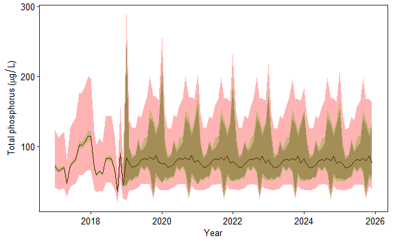

```r
# Plotting the results
ggplot(data = P1concH00.df[which(year(P1concH00.df$date) %in% c(2017:2025)),] )+
  # ggplot(data = P1concH00.df)+
  geom_line(aes(x = date, y = `parhyd50%`))+
  geom_ribbon(aes(x = date, ymin = `hyd5%`, ymax = `hyd95%`), fill = "black", alpha = 0.3)+
  geom_ribbon(aes(x = date, ymin = `parhyd5%`, ymax = `parhyd95%`), fill = "green", alpha = 0.3)+
  geom_ribbon(aes(x = date, ymin = `all5%`, ymax = `all95%`), fill = "red", alpha = 0.3)+
  theme(legend.position = "none")+
  labs(x = "Year",
       y = expression(Total~phosphorus~"("*mu*g/L*")"))+
  plot_basics
```

```r
NA
NA
```

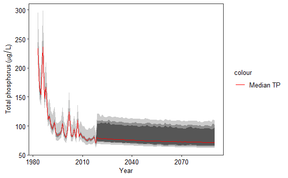

```r
# Plotting the results
ggplot()+
  geom_ribbon(data = P1concH00.df.ann, aes(x = Year, ymin = `hyd5%`, ymax = `hyd95%`), fill = "black", alpha = 0.4)+
  geom_ribbon(data = P1concH00.df.ann, aes(x = Year, ymin = `parhyd5%`, ymax = `parhyd95%`), fill = "black", alpha = 0.3)+
  geom_ribbon(data = P1concH00.df.ann, aes(x = Year, ymin = `all5%`, ymax = `all95%`), fill = "black", alpha = 0.2)+
  geom_line(data = P1concH00.df.ann, aes(x = Year, y = `parhyd50%`, color = "Median TP"))+
  # geom_vline(xintercept = c(2018, 32019, 2020))+
  theme(legend.position = "none")+
  labs(x = "Year",
       y = expression(Total~phosphorus~"("*mu*g/L*")"))+
  scale_color_manual(values = c(`Median TP` = "red"))+
  plot_basics
```

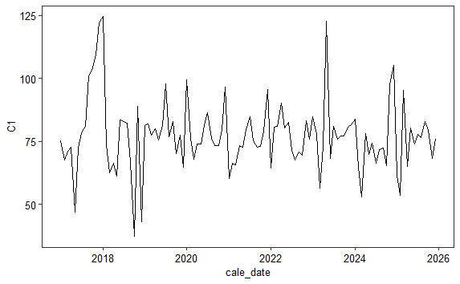

```r
# Checking one future projection timeline
test.dat <- PparhydH00[[1]][[1]]
ggplot(data = test.dat[which(year(test.dat$cale_date) %in% seq(2017,2025)),])+
  geom_line(aes(x = cale_date, y = C1))+
  plot_basics
```

## 9.5 Sediment P Concentration

Let us find the future projections for sediment TP across Jordan Lake with 90% prediction interval.

```r
# Sediment P concentrations
SH00.df <- PI_func(90, "Sconc")
SconcH00.df <- SH00.df[[1]]
SconcH00.df.ann <- SH00.df[[2]]
```

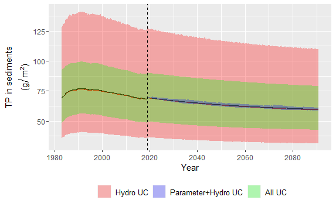

```r
# Plotting the results
ggplot()+
  geom_line(data = SconcH00.df, aes(x = date, y = `parhyd50%`, color = "Median TP"))+
  geom_line(data = SconcH00.df, aes(x = date, y = `hyd_mean`, color = "Mean TP"))+
  geom_ribbon(data = SconcH00.df, aes(x = date, ymin = `all5%`, ymax = `all95%`, fill = "all"), alpha = 0.3)+
  geom_ribbon(data = SconcH00.df, aes(x = date, ymin = `parhyd5%`, ymax = `parhyd95%`, fill = "parhyd"), alpha = 0.3)+
  # geom_ribbon(data = Sconc.df[which(Sconc.df$date %in% date_scen),], aes(x = date, ymin = `hyd5%`, ymax = `hyd95%`, fill = "hyd"), alpha = 0.3)+
  geom_ribbon(data = SconcH00.df, aes(x = date, ymin = `hyd5%`, ymax = `hyd95%`, fill = "hyd"), alpha = 0.3)+
  theme(legend.position = "bottom",
        legend.text = element_text(size = 10))+
  labs(x = "Year",
       y = expression(atop(TP~"in"~sediments,"("*g/m^2*")")))+
  scale_fill_manual("",values = c(`hyd` = "blue",
                               `parhyd` = "green",
                               `all` = "red"),
                    labels = c("Hydro UC", "Parameter+Hydro UC", "All UC"),
                       guide = guide_legend(override.aes =
                                              list(alpha = c(0.1,0.1,0.1))))+
  scale_color_manual("", values = c(`Median TP` = "red",
                                    `Mean TP`= "black"),
                     labels = c(""),
                     guide = "none")+
  # ylim(0,150)+
  geom_vline(xintercept = as.Date("2018-12-31", format = "%Y-%m-%d"), lty = 2)
```

```r
# Saving the file and manually moving it to JLPMv016FutProj folder in output folder
## TP in water
### Monthly
# write.csv(P1concH00.df,"JLPM16P1concH00.df.csv")
### Annual
# write.csv(P1concH00.df.ann,"JLPM16P1concH00.df.ann.csv")

## TP in sediment
### Monthly
# write.csv(SconcH00.df, "JLPM16SconcH00.df.csv")
### Annual
# write.csv(SconcH00.df.ann, "JLPM16SconcH00.df.ann.csv")

## Sediment P release
# write.csv(SresH00.df, "JLPM16SresH00.df.csv")
```

## 9.6 Sediment P release

```r
# Sediment P release
SPresH00.df <- PI_func(90, "Sres")
SresH00.df <- SPresH00.df[[1]]

## Adding seasons
SresH00.df <- SresH00.df %>% mutate(Season = Season(date))
```

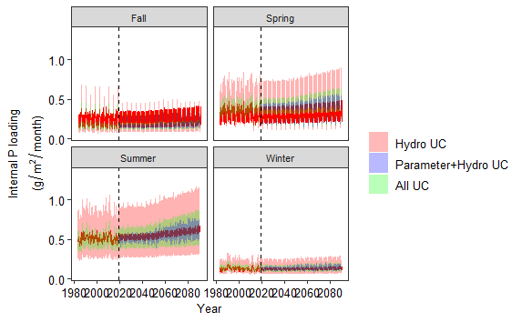

```r
# Plotting the results
ggplot()+
  geom_line(data = SresH00.df, aes(x = date, y = `parhyd50%`, color = "Median TP"))+
  geom_ribbon(data = SresH00.df, aes(x = date, ymin = `all5%`, ymax = `all95%`, fill = "all"), alpha = 0.3)+
  geom_ribbon(data = SresH00.df, aes(x = date, ymin = `parhyd5%`, ymax = `parhyd95%`, fill = "parhyd"), alpha = 0.3)+
  # # geom_ribbon(data = Sres.df[which(Sconc.df$date %in% date_scen),], aes(x = date, ymin = `hyd5%`, ymax = `hyd95%`, fill = "hyd"), alpha = 0.3)+
  geom_ribbon(data = SresH00.df, aes(x = date, ymin = `hyd5%`, ymax = `hyd95%`, fill = "hyd"), alpha = 0.3)+
  facet_wrap(vars(Season))+
  theme(legend.position = "bottom",
        legend.text = element_text(size = 10))+
  labs(x = "Year",
       y = expression(atop(Internal~P~loading,"("*g/m^2/month*")")))+
  scale_fill_manual("",values = c(`hyd` = "blue",
                               `parhyd` = "green",
                               `all` = "red"),
                    labels = c("Hydro UC", "Parameter+Hydro UC", "All UC"),
                       guide = guide_legend(override.aes =
                                              list(alpha = c(0.1,0.1,0.1))))+
  scale_color_manual("", values = c(`Median TP` = "red"),
                     labels = c(""),
                     guide = "none")+
  # ylim(0,200)+
  geom_vline(xintercept = as.Date("2018-12-31", format = "%Y-%m-%d"), lty = 2)+
  plot_basics
```

# 10 Saving the workspace

```r
# Saving the file
# Saving the file [05-10-2023 03:30 PM] # central = mean and accounting for the year to year volume inconsistency; nhist = 60, npar = 1000
# save.image("RWorkSpaces/JLPMv016p006_1.RData")

# Saving the file [05-25-2023 4:30 PM] # central = mean and accounting for the year to year volume inconsistency; nhist = 20, npar = 1000
# save.image("RWorkSpaces/JLPMv016p006_2.RData")
```

# 11 Saving the data frames for future use

```r
# Saving the file and manually moving it to JLPMv016FutProj folder in output folder
## TP in water
### Monthly
write.csv(P1concH00.df,"JLPM16P1concH00.df.csv")
### Annual
write.csv(P1concH00.df.ann,"JLPM16P1concH00.df.ann.csv")

## TP in sediment
### Monthly
write.csv(SconcH00.df, "JLPM16SconcH00.df.csv")
### Annual
write.csv(SconcH00.df.ann, "JLPM16SconcH00.df.ann.csv")

## Sediment P release
write.csv(SresH00.df, "JLPM16SresH00.df.csv")
```

# 12 Preparing better plots for visualization and scrutiny

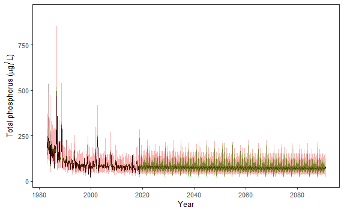

```r
# Segment 1 P concentration
# Projections at monthly scale
ggplot(data = P1concH00.df)+
  geom_line(aes(x = date, y = `parhyd50%`))+
  geom_ribbon(aes(x = date, ymin = `hyd5%`, ymax = `hyd95%`), fill = "black", alpha = 0.5)+
  geom_ribbon(aes(x = date, ymin = `parhyd5%`, ymax = `parhyd95%`), fill = "green", alpha = 0.4)+
  geom_ribbon(aes(x = date, ymin = `all5%`, ymax = `all95%`), fill = "red", alpha = 0.3)+
  theme(legend.position = "none")+
  labs(x = "Year",
       y = expression(Total~phosphorus~"("*mu*g/L*")"))+
  theme_bw()+
  theme(legend.background = element_blank(),
        panel.grid.major = element_blank(),
        panel.grid.minor = element_blank(),
        legend.text.align = 0,
        text = element_text(size = 10),
        legend.text = element_text(size = 10))
```

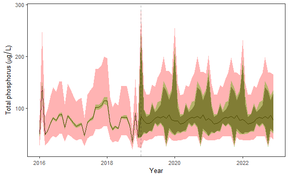

```r
# Segment 1 P concentration
# Projections at monthly scale 2016-2022
ggplot(data = P1concH00.df[which(year(P1concH00.df$date) %in% c(2016:2022)),])+
  geom_line(aes(x = date, y = `parhyd50%`))+
  geom_ribbon(aes(x = date, ymin = `hyd5%`, ymax = `hyd95%`), fill = "black", alpha = 0.5)+
  geom_ribbon(aes(x = date, ymin = `parhyd5%`, ymax = `parhyd95%`), fill = "green", alpha = 0.4)+
  geom_ribbon(aes(x = date, ymin = `all5%`, ymax = `all95%`), fill = "red", alpha = 0.3)+
  # geom_line(data = MassFlows[which(MassFlows$year %in% c(2016:2018)),], aes(x = as.Date(Date, format = "%Y-%m-%d"), y = C1))+
  theme(legend.position = "none")+
  labs(x = "Year",
       y = expression(Total~phosphorus~"("*mu*g/L*")"))+
  theme_bw()+
  theme(legend.background = element_blank(),
        panel.grid.major = element_blank(),
        panel.grid.minor = element_blank(),
        legend.text.align = 0,
        text = element_text(size = 10),
        legend.text = element_text(size = 10))+
  geom_vline(xintercept = as.Date("2019-01-01", format = "%Y-%m-%d"), lty = 2, alpha = 0.3)
```

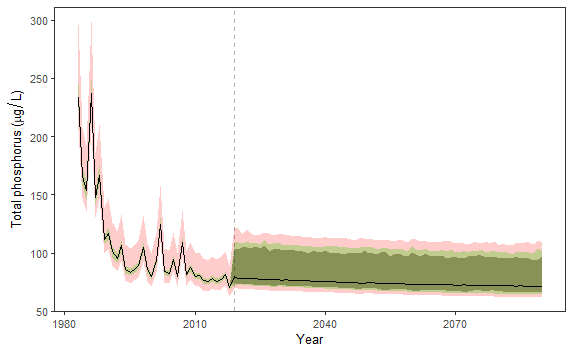

```r
# Segment 1 P concentration (annual values)
# Plotting the results
ggplot(data = P1concH00.df.ann)+
  geom_ribbon(aes(x = Year, ymin = `hyd5%`, ymax = `hyd95%`), fill = "black", alpha = 0.4)+
  geom_ribbon(aes(x = Year, ymin = `parhyd5%`, ymax = `parhyd95%`), fill = "green", alpha = 0.3)+
  geom_ribbon(aes(x = Year, ymin = `all5%`, ymax = `all95%`), fill = "red", alpha = 0.2)+
  geom_line(aes(x = Year, y = `parhyd50%`, color = "Median TP"))+
  geom_vline(xintercept = 2019, lty = 2, alpha = 0.3)+
  theme(legend.position = "none")+
  labs(x = "Year",
       y = expression(Total~phosphorus~"("*mu*g/L*")"))+
  scale_color_manual(values = c(`Median TP` = "black"))+
  theme_bw()+
  theme(legend.background = element_blank(),
        panel.grid.major = element_blank(),
        panel.grid.minor = element_blank(),
        legend.position = "none",
        legend.text.align = 0,
        text = element_text(size = 10),
        legend.text = element_text(size = 10))
```

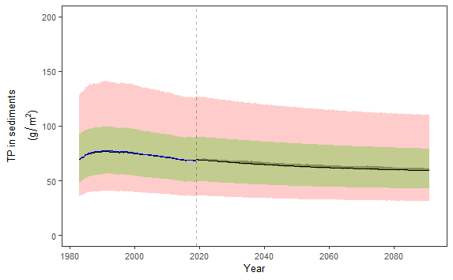

```r
# Sediment P concentration
# Plotting the results
ggplot(data = SconcH00.df)+
  geom_ribbon(aes(x = date, ymin = `hyd5%`, ymax = `hyd95%`), fill = "black", alpha = 0.4)+
  geom_ribbon(aes(x = date, ymin = `parhyd5%`, ymax = `parhyd95%`), fill = "green", alpha = 0.3)+
  geom_ribbon(aes(x = date, ymin = `all5%`, ymax = `all95%`), fill = "red", alpha = 0.2)+
  geom_line(aes(x = date, y = `parhyd50%`, color = "Median TP"))+
  geom_line(data = (MassFlows %>% mutate(Sconc = (S1+S2+S3+S4)/(49.02*10^3))), aes(x = as.Date(Date, format = "%Y-%m-%d"), y = Sconc), color = "blue")+
  theme(legend.position = "none")+
  labs(x = "Year",
       y = expression(atop(TP~"in"~sediments,"("*g/m^2*")")))+
  ylim(0,200)+
  scale_color_manual(values = c(`Median TP` = "black"))+
  geom_vline(xintercept = as.Date("2019-01-01", format = "%Y-%m-%d"), lty = 2, alpha = 0.3)+
  theme_bw()+
  theme(legend.background = element_blank(),
        panel.grid.major = element_blank(),
        panel.grid.minor = element_blank(),
        legend.position = "none",
        legend.text.align = 0,
        text = element_text(size = 10),
        legend.text = element_text(size = 10))
```

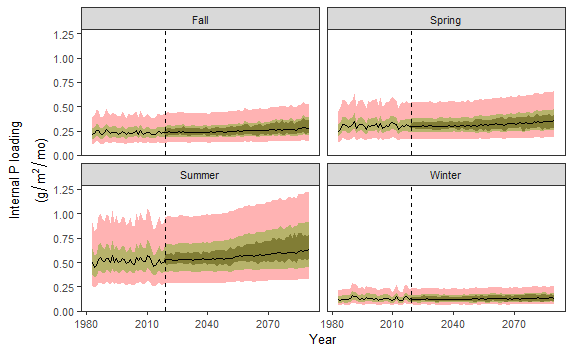

```r
# Sediment P release
# Monthly projections
ggplot(data = (SresH00.df %>% mutate(year = year(date)) %>% group_by(Season, year) %>% summarise(
  `hyd5%` = mean(`hyd5%`),
  `hyd50%` = mean(`hyd50%`),
  `hyd95%` = mean(`hyd95%`),
  `parhyd5%` = mean(`parhyd5%`),
  `parhyd50%` = mean(`parhyd50%`),
  `parhyd95%` = mean(`parhyd95%`),
  `all5%` = mean(`all5%`),
  `all50%` = mean(`all50%`),
  `all95%` = mean(`all95%`))))+
  geom_ribbon(aes(x = year, ymin = `hyd5%`, ymax = `hyd95%`, fill = "hyd"), alpha = 0.5)+
  geom_ribbon(aes(x = year, ymin = `parhyd5%`, ymax = `parhyd95%`, fill = "parhyd"), alpha = 0.4)+
  geom_ribbon(aes(x = year, ymin = `all5%`, ymax = `all95%`, fill = "all"), alpha = 0.3)+
  geom_line(aes(x = year, y = `parhyd50%`, color = "Median TP"))+
  facet_wrap(vars(Season))+
  theme(legend.position = "bottom",
        legend.text = element_text(size = 10))+
  labs(x = "Year",
       y = expression(atop(Internal~P~loading,"("*g/m^2/mo*")")))+
  scale_fill_manual("",values = c(`hyd` = "black",
                               `parhyd` = "green",
                               `all` = "red"),
                    labels = c("Hydro UC", "Parameter+Hydro UC", "All UC"),
                       guide = guide_legend(override.aes =
                                              list(alpha = c(0.1,0.1,0.1))))+
  scale_color_manual("", values = c(`Median TP` = "black"),
                     labels = c(""),
                     guide = "none")+
  # ylim(0,200)+
  geom_vline(xintercept = 2019, lty = 2)+
  theme_bw()+
  theme(legend.background = element_blank(),
        panel.grid.major = element_blank(),
        panel.grid.minor = element_blank(),
        legend.text.align = 0,
        text = element_text(size = 10),
        legend.text = element_text(size = 10),
        legend.position = "none")
```

```r
# Start timer
End_timer6 <- Sys.time()

# Total time taken to run the entire notebook
Tot_time6 <- End_timer6 - Start_timer6
Tot_time6
```

```
Time difference of 15.22497 hours
```

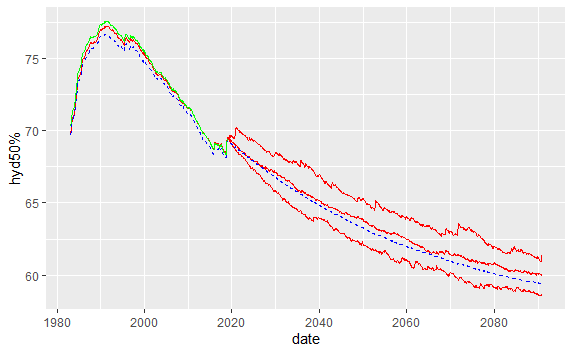

```r
MassFlows1 <- (MassFlows %>% mutate(Sconc = (S1+S2+S3+S4)/(49.02*10^3)))
ggplot(SconcH00.df)+
  geom_line(aes(x = date, y = `hyd50%`), color = "red")+
  geom_line(aes(x = date, y = `hyd5%`), color = "red")+
  geom_line(aes(x = date, y = `hyd95%`), color = "red")+
  geom_line(aes(x = date, y = `parhyd50%`), color = "blue", lty = 2)+
  # geom_line(aes(x = date, y = `all50%`), color = "black", lty = 2)+
  # geom_line(aes(x = date, y = `hyd_mean`), color = "black")+
  geom_line(data = MassFlows1, aes(x = SconcH00.df$date[1:432], y = Sconc), color = "green")
```

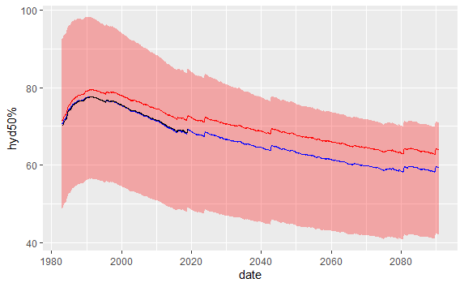

```r
# Selecting one future timeline out of 20
PI = 90
nhistx = 20
nparx = 10
Cx = "Sconc"

PI_low <- (100-PI)/2 # lower limit
PI_high <- PI+ (100-PI)/2 # upper limit

# Future projections with hydrologic uncertainty
## blank list
Cxh.lst <- list()

  ## Taking the mean or median for each historical year
for (i in 1:nhistx){
# i <- 1
tmpx.df <- data.frame(date = c(date_cali, date_scen))

for (j in 1:nparx){
  Mod <- paste0("Year",i+1998,"n",j)
  tmpx.df <- cbind(tmpx.df, PparhydH00[[i]][[j]][,Cx])
  colnames(tmpx.df)[ncol(tmpx.df)] <- Mod
    }

Cxh.lst[[i]] <- tmpx.df %>%
  # mutate(central = apply(select(.,-date),1, mean))
  mutate(central = apply(select(.,-date),1, median))
}

  ## Pulling the central value out of the list and renaming the data frame with respective historical years
  Cxh.df <- Cxh.lst %>% sapply(.,"[[", "central") %>% as.data.frame() %>% `colnames<-`(.,seq(1, nhistx))



## Adding Date to the data frame
Cxh.df <- Cxh.df %>% mutate(date = c(date_cali, date_scen),
                                  Year = year(date))

## one future timeline
Cxh.df1 <- Cxh.lst[[20]][,1:(ncol(Cxh.lst[[1]])-1)]

## Estimating the quantilies
Cxh.df1.med <- apply(Cxh.df1[,2:ncol(Cxh.df1)], 1 ,quantile ,probs =c((PI_low/100),.5,(PI_high/100))) %>%
    t %>% as.data.frame() %>%
    mutate(date = c(date_cali, date_scen))%>%
    rename_at(vars(-date),function(x) paste0("hyd",x)) %>%
  mutate(hyd_mean = apply(Cxh.df1[,2:ncol(Cxh.df1)], 1 ,mean))


 ggplot(data = Cxh.df1.med)+
   geom_ribbon(aes(x = date, ymin = `hyd5%`, ymax = `hyd95%`), fill = "red", alpha = 0.3)+
   geom_line(aes(x = date, y = `hyd50%`), color = "red")+
   geom_line(aes(x = date, y = hyd_mean), color = "blue")+
 geom_line(data = (MassFlows %>% mutate(Sconc = (S1+S2+S3+S4)/(49.02*10^3))), aes(x = as.Date(Date, format = "%Y-%m-%d"), y = Sconc), color = "black")
```

```r
NA
NA
```

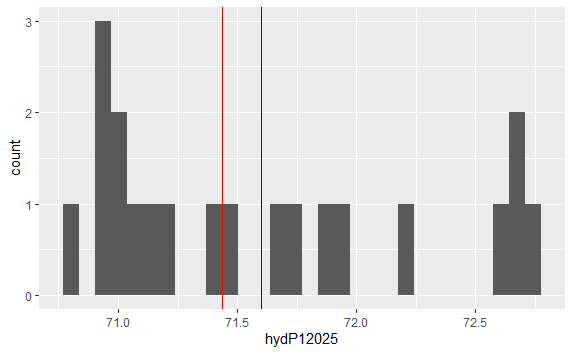

```r
# plotting hyd C1 distribution in 2025
hydP12025 <- as.numeric(Cxh.df[505,1:20])

ggplot()+
  geom_histogram(aes(x = hydP12025))+
  geom_vline(xintercept = mean(hydP12025), color = "blue")+
  geom_vline(xintercept = median(hydP12025), color = "red")
```

```r
Cx.df <- data.frame(date = c(date_cali, date_scen))
  for (i in 1:nhistx){
    for (j in 1:nparx){
      Mod <- paste0("Year",i+1998,"n",j)
      Cx.df <- cbind(Cx.df, PparhydH00[[i]][[j]][,Cx])
      colnames(Cx.df)[ncol(Cx.df)] <- Mod
    }
  }
```

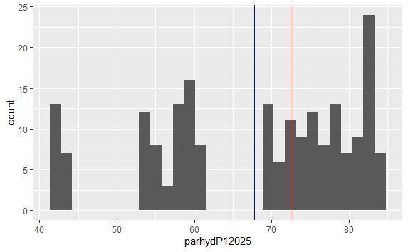

```r
# plotting hyd C1 distribution in 2025
parhydP12025 <- as.numeric(Cx.df[505,2:200])

ggplot()+
  geom_histogram(aes(x = parhydP12025))+
  geom_vline(xintercept = mean(parhydP12025), color = "blue")+
  geom_vline(xintercept = median(parhydP12025), color = "red")
```

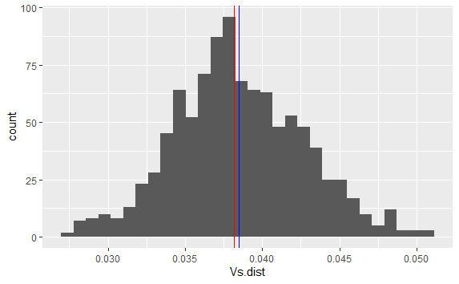

```r
# Check on the parameter distribution
set.seed(500)
postPsmpl.temp <- RAM$samples[sample(seq((nrow(RAM$samples)-25000),nrow(RAM$samples)), 1000, replace = F),]

Vs.dist <- postPsmpl.temp[,"Vs"]
ggplot()+
  geom_histogram(aes(x = Vs.dist))+
  geom_vline(xintercept = mean(Vs.dist), color = "blue")+
  geom_vline(xintercept = median(Vs.dist), color = "red")
```

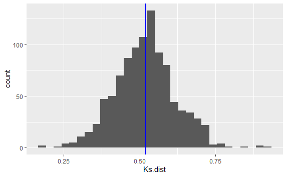

```r
Ks.dist <- postPsmpl.temp[,"Ks"]
ggplot()+
  geom_histogram(aes(x = Ks.dist))+
  geom_vline(xintercept = mean(Ks.dist), color = "blue")+
  geom_vline(xintercept = median(Ks.dist), color = "red")
```

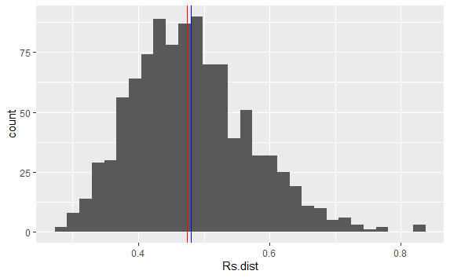

```r
Rs.dist <- postPsmpl.temp[,"Rs"]
ggplot()+
  geom_histogram(aes(x = Rs.dist))+
  geom_vline(xintercept = mean(Rs.dist), color = "blue")+
  geom_vline(xintercept = median(Rs.dist), color = "red")
```

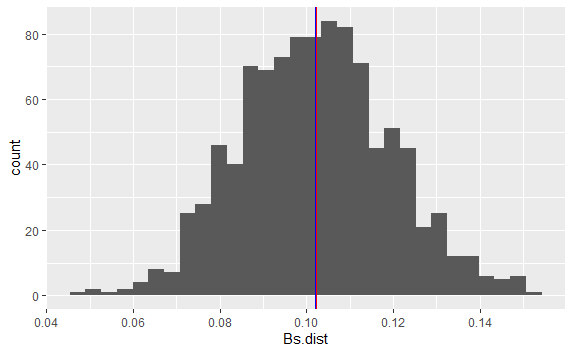

```r
Bs.dist <- postPsmpl.temp[,"Bs"]
ggplot()+
  geom_histogram(aes(x = Bs.dist))+
  geom_vline(xintercept = mean(Bs.dist), color = "blue")+
  geom_vline(xintercept = median(Bs.dist), color = "red")
```

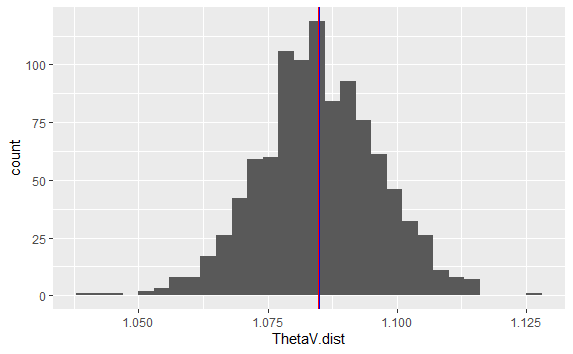

```r
ThetaV.dist <- postPsmpl.temp[,"ThetaV"]
ggplot()+
  geom_histogram(aes(x = ThetaV.dist))+
  geom_vline(xintercept = mean(ThetaV.dist), color = "blue")+
  geom_vline(xintercept = median(ThetaV.dist), color = "red")
```

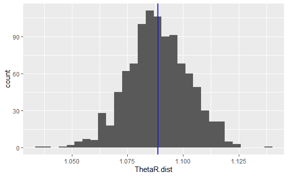

```r
ThetaR.dist <- postPsmpl.temp[,"ThetaR"]
ggplot()+
  geom_histogram(aes(x = ThetaR.dist))+
  geom_vline(xintercept = mean(ThetaR.dist), color = "blue")+
  geom_vline(xintercept = median(ThetaR.dist), color = "red")
```

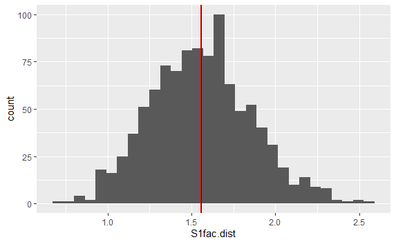

```r
S1fac.dist <- postPsmpl.temp[,"S1fac"]
ggplot()+
  geom_histogram(aes(x = S1fac.dist))+
  geom_vline(xintercept = mean(S1fac.dist), color = "blue")+
  geom_vline(xintercept = median(S1fac.dist), color = "red")
```

```r
mean(S1fac.dist)
```

```
[1] 1.556704
```

# 13 Segment 1 Volume and Mass

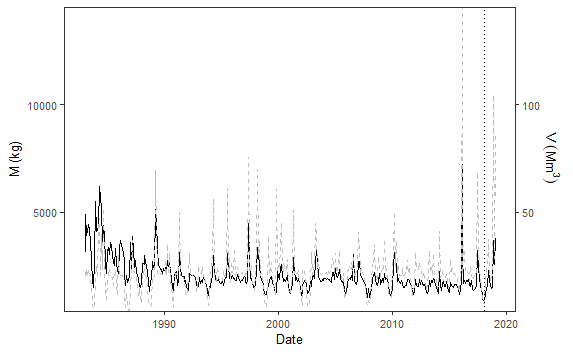

```r
ggplot()+
  geom_line(data = MassFlows, aes(x = Date, y = M1), color = "black")+
  geom_line(data = RoutMOdin, aes(x = MassFlows$Date, y = (V1*100)), lty = 2, color = "grey")+
  geom_vline(xintercept = MassFlows$Date[421], lty = 3)+
  scale_y_continuous(name = expression(M~"("*kg*")"),
                       sec.axis = sec_axis(trans = ~((./100)) ,
                                           name = expression(V~(Mm^3))),
                     expand = c(0, 0))+
  theme_bw()+
  theme(legend.background = element_blank(),
        panel.grid.major = element_blank(),
        panel.grid.minor = element_blank(),
        legend.text.align = 0,
        text = element_text(size = 10),
        legend.text = element_text(size = 10),
        legend.position = "none")
```